# АНАЛИЗ ДАННЫХ В СОЦИАЛЬНЫХ НАУКАХ С ПОМОЩЬЮ ЯЗЫКА R

## Продолжим!

## Формат файла .Rdata

В R есть свой собственный формат данных, в котором можно сохранить коллекцию R объектов или “слепок” сразу всего Workspace.

Давайте сделаем свой файл load.R

```r
#это файл с загрузкой данных!
data<-read.table(file="data/iGLAS for R course.csv",sep=",",
                  quote = "\"", header=T,fileEncoding = "UTF-8-BOM")
five_point_scales<-grep("i5",names(data),value = T)
save(data,five_point_scales,file="data/iGLAS.Rdata")
```

Вот это вот запишите в новый файл load.R, сохранив его в корневой папке проекта.

## Как удалить вообще всё из памяти

1. Кнопка-метёлка в окне Environment
2. Команда *rm(list=ls())*
3. Перезапустить R через Session -> Terminate R

А теперь, после того, как всё удалили, просто загрузите данные из записанного файла:

```r
load("data/iGLAS.Rdata")
```

А ещё, можно запускать код любого другого R-скрипта через команду source:

```r
source("load.R")
```

Если вы исполняете такой файл, результаты его исполнения сохраняются в памяти и вам не нужны промежуточные файлы.

## Внимание, вопрос:

### Так зачем же сохранять промежуточные файлы .Rdata?

## целые числа

Сегодня мы продолжим изучение различных типов данных в R.

Начнём с целых чисел. Ограничения на целочисленные выражения. Подробнее документацию можно изучить, запустив команды ?integer и ?double.

```r
int_num<-c(1,2,3,4000)
int_num<-as.integer(c(1,2,3,4000))
as.integer(214748364.7)
as.integer(2147483648)
as.integer(-2147483647)
as.integer(-2147483648)
as.double("10000998843483274893274892374238947273")
options(scipen=100)
2^64
90071992547409923
100000000/20000000
```

## числа с десятичной долей (double)

```r
numeric_num<-c(1,2,2.5)
is.integer(numeric_num)
is.integer(int_num)
is.numeric(int_num)
is.numeric(numeric_num)
str(numeric_num)
is.double(numeric_num)
typeof(numeric_num)
class(numeric_num)
```

## Генерирование случайных чисел

Континуальные числа:

```r
#равномерное распределение:
unif<-runif(100)
unif<-runif(100,min = 0,max=100)
#нормальное:
norm<-rnorm(100)
norm<-rnorm(100000,mean = 50,sd = 10)
```

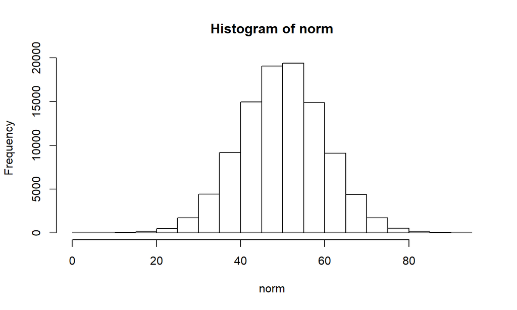

```r
hist(norm)
```

Дискретные числа:

```r
sample(x = 1:100,size = 10)
```

```
##  [1] 12 10  3 47 63 18 57 16 40  2
```

```r
sample(1:2,10,replace = T)
```

```
##  [1] 2 2 1 1 2 2 2 2 2 1
```

```r
sample(10,2)
```

```
## [1] 7 2
```

## shuffle вектора

Если на вход sample подать просто вектор, то size по умолчанию равен длине этого вектора. Получится тот же вектор, но случайным образом перемешанный.

```r
sample(LETTERS[1:3]) #LETTERS - встроенный в базовый R вектор-заготовка с буквами английского алфавита
```

```
## [1] "A" "C" "B"
```

Ещё немного про генерацию данных…

```r
#команда rep - очень удобная штука...

rep(c(1:3),times=3)
```

```
## [1] 1 2 3 1 2 3 1 2 3
```

```r
rep(1:3,each=3)
```

```
## [1] 1 1 1 2 2 2 3 3 3
```

```r
rep(1:2,times=2,each=2)
```

```
## [1] 1 1 2 2 1 1 2 2
```

```r
#удобная команда seq

seq(from = 1,to = 20,by = 2)
```

```
##  [1]  1  3  5  7  9 11 13 15 17 19
```

```r
#враппер
seq_len(10)
```

```
##  [1]  1  2  3  4  5  6  7  8  9 10
```

## Базовые операции с числовыми векторами

```r
mean(norm,na.rm = T)
```

```
## [1] 49.99395
```

```r
median(norm,na.rm=T)
```

```
## [1] 50.01592
```

```r
sd(norm,na.rm=T)
```

```
## [1] 10.0392
```

```r
max(norm,na.rm=T)
```

```
## [1] 92.78909
```

```r
min(norm,na.rm=T)
```

```
## [1] 2.032398
```

```r
length(norm) # но это к любому объекту применимо
```

```
## [1] 100000
```

```r
length(data)
```

```
## [1] 329
```

## Разрежем наш вектор!

Обратите внимание на такие аргументы, как right и include.lowest. Они дают несколько вариантов действий с теми значениями, которые попадают строго на границу интервалов. В случае переменных границ интервалов лучше использовать Inf и -Inf в качестве крайних границ диапазонов. Количество диапазонов равно количеству границ минус один.

```r
a<-c(1:5)
cut(a,breaks = c(2,4))
cut(a,breaks = c(-Inf,3,Inf))
cut(a,breaks = c(-Inf,3,Inf),right = F)
```

Уровням можно присваивать имена!

```r
a<-c(1:5)
cut(a,breaks = c(-Inf,2,4,Inf),right = F,labels = c("l","m","h"))
```

```
## [1] l m m h h
## Levels: l m h
```

## А теперь - процентиль!

Вернее - квантиль. Эти свойства распределения в паре с командой cut удобно использовать для того, чтобы изменять распределение. Например, [нелинейная нормализация](https://en.wikipedia.org/wiki/Sten_scores).

```r
quantile(norm,c(0.1,0.5,0.9))
```

```
##      10%      50%      90%
## 37.14993 50.01592 62.83423
```

## Факторы

Вот то, что было результатом выполнения команды cut - это был фактор! Факторы - это закодированные упорядоченные значения уровней фактора. По умолчанию уровни фактора расставляются по алфавиту.  
Можно менять порядок уровней:

```r
a<-factor(c("плохо","так себе","так себе","хорошо","отлично","отлично"))
levels(a)
```

```
## [1] "отлично"  "плохо"    "так себе" "хорошо"
```

```r
fl<-c("плохо","так себе","хорошо","отлично")
a<-factor(a,levels=fl)
levels(a)
```

```
## [1] "плохо"    "так себе" "хорошо"   "отлично"
```

Можно перекодировать значения переменных, просто заменяя вектор уровней фактора:

```r
levels(a)<-c("тошнотворно", "отвратительно", "так себе", "сойдёт")
a
```

```
## [1] тошнотворно   отвратительно отвратительно так себе      сойдёт
## [6] сойдёт
## Levels: тошнотворно отвратительно так себе сойдёт
```

Более того, можно уровни фактора объединять в один:

```r
levels(a)<-c("тошнотворно", "тошнотворно", "тошнотворно", "сойдёт")
a
```

```
## [1] тошнотворно тошнотворно тошнотворно тошнотворно сойдёт      сойдёт
## Levels: тошнотворно сойдёт
```

Числовой вектор тоже можно превратить в фактор:

```r
num<-c(1,1,2,3,3,1,5,4,2)
num<-factor(num)
```

После этого можно ввести расшифровку этих уровней:

```r
levels(num)<-c("Strongly disagree",
"Disagree",
"Neither agree nor disagree",
"Agree",
"Strongly agree")
num
```

```
## [1] Strongly disagree          Strongly disagree
## [3] Disagree                   Neither agree nor disagree
## [5] Neither agree nor disagree Strongly disagree
## [7] Strongly agree             Agree
## [9] Disagree
## 5 Levels: Strongly disagree Disagree Neither agree nor disagree ... Strongly agree
```

Факторы могут быть упорядоченными (как ранговая шкала):

```r
a<-factor(a,ordered=T)
str(a)
```

```
##  Ord.factor w/ 2 levels "тошнотворно"<..: 1 1 1 1 2 2
```

очень неприятный случай, которого лучше избегать - преобразование в количественную шкалу фактора, созданного и смеси текста и чисел:

```r
a<-factor(c("0","нет ответов","1","2","3"))
levels(a)
```

```
## [1] "0"           "1"           "2"           "3"           "нет ответов"
```

```r
as.character(a)
```

```
## [1] "0"           "нет ответов" "1"           "2"           "3"
```

```r
as.numeric(a)
```

```
## [1] 1 5 2 3 4
```

Чтобы с этим справиться, надо сперва фактор преобразовать в character, а уж потом в numeric.

```r
as.numeric(as.character(a))
```

```
## [1]  0 NA  1  2  3
```

И препятствовать появлению факторов при импорте файла:

```r
data<-read.table(file="data/iGLAS for R course.csv",sep=",",
                  quote = "\"", header=T,fileEncoding = "UTF-8-BOM")
data2<-read.table(file="data/iGLAS for R course.csv",sep=",",
                  quote = "\"", header=T,fileEncoding = "UTF-8-BOM",
                  stringsAsFactors = F)
```

Посмотрим, какова разница между датафреймом с факторами и с простыми строками:

```r
object.size(data)
```

```
## 10283672 bytes
```

```r
object.size(data2)
```

```
## 10489432 bytes
```

## Строки

```r
a<-c("мыла","мама", "раму")
typeof(a)
```

```
## [1] "character"
```

Операции сравнения возможны и со строками!

```r
a[a>"мы"]
```

```
## [1] "мыла" "раму"
```

```r
a[a=="мыла"]
```

```
## [1] "мыла"
```

Практическая польза!

```r
b<-c("2018-07-25","2018-07-28")
b < "2018-07-26"
```

```
## [1]  TRUE FALSE
```

```r
dates<-c("2017-07-26","2017-07-29","2017-08-20","2016-06-30","2017-02-29")

dates[dates<"2017-07-27"]
```

```
## [1] "2017-07-26" "2016-06-30" "2017-02-29"
```

Строки можно объединять с помошью paste. Векторов может быть много!

```r
a<-LETTERS[1:10]
b<-1:10
c<-1:5
paste(a,b,c,sep="$")
```

```
##  [1] "A$1$1"  "B$2$2"  "C$3$3"  "D$4$4"  "E$5$5"  "F$6$1"  "G$7$2"
##  [8] "H$8$3"  "I$9$4"  "J$10$5"
```

```r
paste("var_",b,sep="")
```

```
##  [1] "var_1"  "var_2"  "var_3"  "var_4"  "var_5"  "var_6"  "var_7"
##  [8] "var_8"  "var_9"  "var_10"
```

Слияние всех элементов вектора - через collapse:

```r
paste(a,collapse="")
```

```
## [1] "ABCDEFGHIJ"
```

```r
paste(a,collapse=" ")
```

```
## [1] "A B C D E F G H I J"
```

## логические векторы

Повторение - мать учения. :-)

```r
a<-c(T,F,F,F,T,NA)
which(a)
which(!a)
```

Чаще всего логические векторф используются для фильтрации

```r
v<-c("мама", "мыла", "раму", "мыла", "было", "мало")
v[a]
```

[output not shown]

Обратите внимание на NA. Если в логическом векторе есть пропуски, то фильтровать им нельзя!

## логические векторы

Зато можно так:

```r
v<-c("мама", "мыла", "раму", "мыла", "было", "мало")
a<-c(T,F,F,F,T,NA)
v[which(a)]
```

```
## [1] "мама" "было"
```

В R действует одновременно три разных способа фильтрации объектов:

1. с помощью вектора с адресами (номерами строк)
2. с помощью вектора с именами
3. С помощью логического вектора

Списки и датафреймы

```r
u=list("A", 1, list ("A", T))
str(u) #обратите внимание на str - команда показывает структуру данных
```

```
## List of 3
##  $ : chr "A"
##  $ : num 1
##  $ :List of 2
##   ..$ : chr "A"
##   ..$ : logi TRUE
```

```r
uu<-c(list("a",5),list(list(5)))
unlist(u)
```

```
## [1] "A"    "1"    "A"    "TRUE"
```

```r
u<-list("a"=c(1,2),"b"=c(3,4))
u2<-as.data.frame(u)
```

## Адресация в списках

```r
u=list("A", 1, list ("A", T))
#как обратитьcя, чтобы получить T?
u[[3]][[2]]
```

```
## [1] TRUE
```

```r
#в чём разница [[]] и []?
str(u[1])
```

```
## List of 1
##  $ : chr "A"
```

```r
str(u[[1]])
```

```
##  chr "A"
```

Задание для самостоятельной работы:

1. Вспомните всё про факторы. В ваших данных есть переменная data$iDgender. Превратите её в фактор со значениями согласно документации опроса.
2. Создайте файл clean.R и включите в него код c предыдущего занятия, в котором заменяли возраст старше 95 лет на пропуски. Перед этим там надо загрузить данные из сохранённого сегодня файла .Rdata
3. Создайте файл analyze_age.R и из него запустите clean.R Следующие два задания делайте в нём.
4. Вспомните про фильтрацию с помощью логических векторов. Посчитайте средний возраст для мужчин и для женщин отдельно.
5. Разбейте возраст на три группы по 25 и 75 процентилю, создав переменную data$age_group c именами групп “young”, “middle”, “old”.

продолжение на следующей странице!

1. Создайте переменную x, которая будет содержать данные, составляющие следующий ряд (заполнить пропущенное):

“10a”,“15b”,“20c”,“25a”,“30b”, …, “200c”

Проверка:

sum(strtoi(x,16))==138141

1. Создайте переменную, которая будет содержать данные, составляющие следующий ряд (заполнить пропущенное):

“1207a” “1327b” “1448c” “1568a” “1689b” “1809c” “1927a” “2047b” “2168c” “2288a” “2409b” … “4689c”  
Проверка: sum(strtoi(x,16))==5417034

Нет, тут нет опечаток :-)